# **Analyzing Ford GoBike System Data**

### Introduction

Ford GoBike is a public bicycle-sharing system in the San Francisco Bay Area of California. Currently, the Ford GoBike network has over 2,600 bicycles in 262 stations across San Francisco, East Bay and San Jose, beginning service in August 2013 as a Bay Area Bike Share. The system was officially launched on 28 June 2017 as Ford GoBike in conjunction with Ford Motor Company.

# Univariate exploration

## 1. Histogram for duration_min

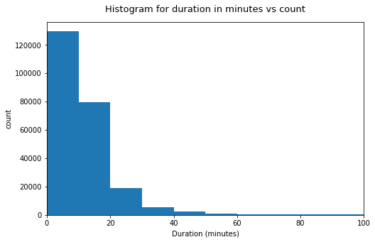

```python
#Plotting the histogram for duration of minutes
bin_sizes = 10
bins = np.arange(0, df_clean['duration_min'].max()+bin_sizes, bin_sizes)

#plotting the histogram
plt.figure(figsize=[8, 5])
plt.hist(data = df_clean, x = 'duration_min', bins=bins);
plt.xlim(0,100)
plt.xlabel('Duration (minutes)');
plt.ylabel('count');
plt.title('Histogram for duration in minutes vs count', y=1.03, fontsize=13 );
```

It can be observed from the graph above that most of the data is below 50.

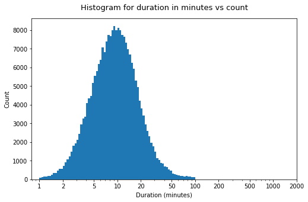

```python
#finding the log scale
log_bin_sizes = 0.025
bins = 10 ** np.arange(0, np.log10(df_clean['duration_min'].max())+log_bin_sizes, log_bin_sizes)
#plotting the histogram
plt.figure(figsize=[8, 5]);
plt.hist(data = df_clean, x = 'duration_min', bins = bins);
plt.xscale('log');

xtick=[1, 2, 5, 10, 20, 50, 100, 200, 500, 1000, 2000]
plt.xticks(xtick,xtick);
plt.xlabel('Duration (minutes)');
plt.ylabel('Count');
plt.title('Histogram for duration in minutes vs count', y=1.03, fontsize=13 );
```

It is pretty clear from the graph that this looks like a normal distribution.

## 2. Countplot for start_time_hour

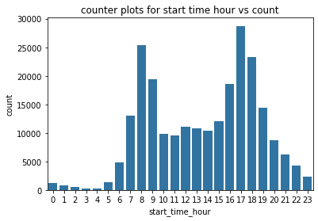

```python
#seeting the colors
colors = sb.color_palette()[0]
sb.countplot(data = df_clean, x = 'start_time_hour', color = colors);
plt.title("counter plots for start time hour vs count")
```

It is pretty evident from the histogram that the number of bikers are highest at 5pm followed by 8am.

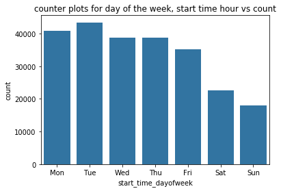

```python
#plotting for days of the week
sb.countplot(data = df_clean, x = 'start_time_dayofweek', color = colors);
plt.title("counter plots for day of the week, start time hour vs count")
```

We see that tuesday has the highest number of bikers followed by Monday in the above graph

**Discuss the distribution(s) of your variable(s) of interest. Were there any unusual points? Did you need to perform any transformations?**

The histogram plot for duration in minutes, I figured that most were below 50 minutes, but with a very few users with over 50 minutes which resulted in a long tail . So, I used a log histogram lot to remove the tail.

**Of the features you investigated, were there any unusual distributions? Did you perform any operations on the data to tidy, adjust, or change the form of the data? If so, why did you do this?**

Apart from the one mentioned above, I made tidied the data by removing all the null values during the cleaning part of the process.

# Bivariate exploration

## 1. Plotting Heatmap for all the columns

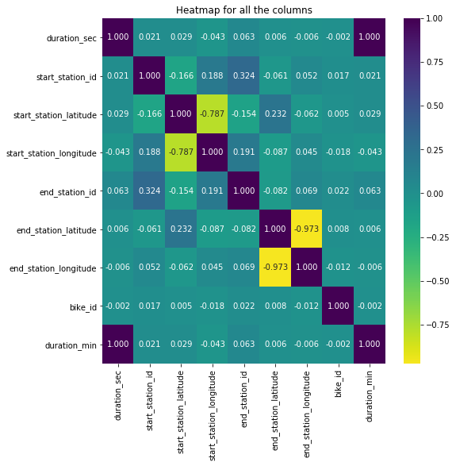

```python
#plotting the heatmap
plt.figure(figsize = [8, 8])
plt.title("Heatmap for all the columns")
sb.heatmap(df_clean[num_cols].corr(), annot = True, fmt = '.3f', cmap = 'viridis_r', center = 0);
```

In these pairs (start_station_id, end_station_id), (start_station_latitude, start_station_longitude), and (end_station_latitude, end_station_longitude), the coefficients indicate that there might be some correlations.

## 2.Countplots for day_of_week, start_time_hour and user_type

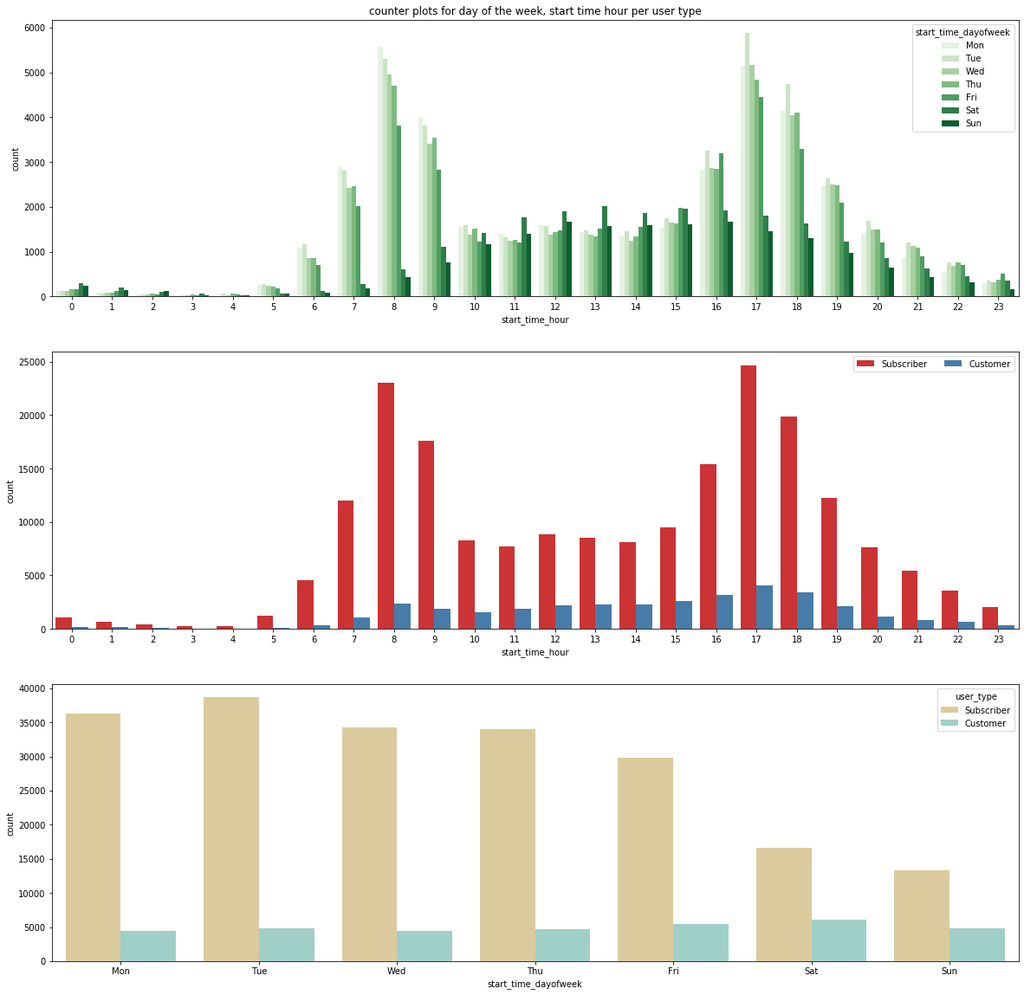

```python
#plotting th figure
plt.figure(figsize = [20, 20]);


#subplots
plt.subplot(3, 1, 1);
sb.countplot(data = df_clean, x = 'start_time_hour', hue = 'start_time_dayofweek', palette = 'Greens');
plt.title("counter plots for day of the week, start time hour per user type")

ax1 = plt.subplot(3, 1, 2);

sb.countplot(data = df_clean, x = 'start_time_hour', hue = 'user_type', palette = 'Set1');
#rearranging
ax1.legend(loc = 1, ncol = 2);
ax1 = plt.subplot(3, 1, 3);
sb.countplot(data = df_clean, x = 'start_time_dayofweek', hue = 'user_type', palette = 'BrBG');
```

**Observations from the above graphs**

Tuesday 5:00 PM has the highest biker counts across all 7 days and 24 hours.

5:00 PM has the most 'Subscriber' and 'Customer' bikers .

Tuesday has the most 'Subscriber' bikers , whereas Saturday has the most 'Customer' bikers compared to other days.

**Talk about some of the relationships you observed in this part of the investigation. How did the feature(s) of interest vary with other features in the dataset?**

Customers have longer Trip duration for than subscribers.

Bikers ride more often at 5pm in the early evening or at 8 am in the early morning.

Tuesday has the most bikers when compared to other days.

**Did you observe any interesting relationships between the other features (not the main feature(s) of interest)? Observations from above plots:**

5:00pm tuesday sees an all time high in the biker counts.

Compared to other hours ,5:00 PM has the most 'Subscriber' and 'Customer' bikers.

# Multivariate Exploration

## 1.Plotting Hour vs user type per day

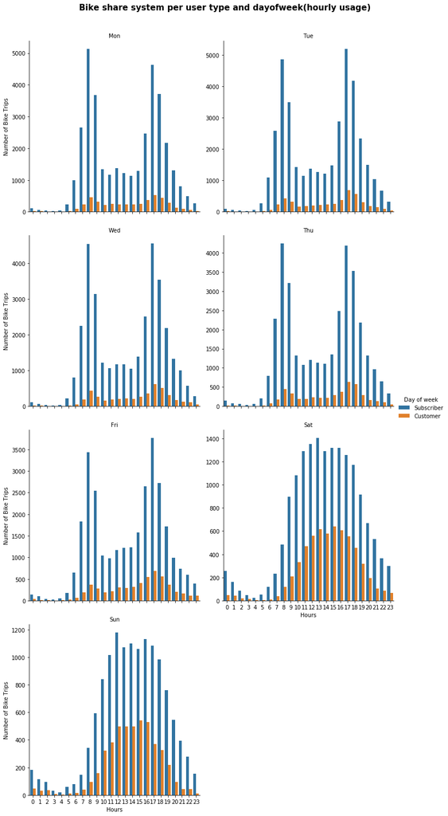

```python
#Plotting the graph
gh = sb.catplot(data=df_clean, x='start_time_hour', col="start_time_dayofweek", hue='user_type', kind='count', sharey = False,col_wrap=2)
gh.set_axis_labels("Hours", "Number of Bike Trips")



#setting labels
gh._legend.set_title('Day of week')
gh.set_titles("{col_name}")
gh.fig.suptitle( 'Bike share system per user type and dayofweek(hourly usage)', y=1.03, fontsize=15, fontweight='semibold');
```

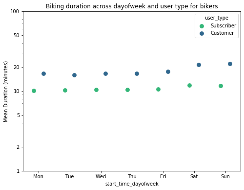

```python
#plotting the figure
fig1 = plt.figure(figsize = [8,6]);
ax1 = sb.pointplot(data = df_clean, x = 'start_time_dayofweek', y = 'duration_min', hue = 'user_type',
           palette = 'viridis_r', linestyles = '', dodge = 0.3);
#setting titles and labels
plt.title('Biking duration across dayofweek and user type for bikers');
plt.ylabel('Mean Duration (minutes)');
plt.yscale('log');
plt.yticks([1, 2, 5, 10, 20, 50, 100], [1, 2, 5, 10, 20, 50, 100]);
ax1.set_yticklabels([],minor = True);
```

The plot shows that the duration is more customer user type across all days, with maximum being on the weekends.

**Talk about some of the relationships you observed in this part of the investigation. Were there features that strengthened each other in terms of looking at your feature(s) of interest?**

According to the above graphs, the features we studied here are exactly related to each other. We haven't observed features as such that reinforced one another in looking at features to my interest.

**Were there any interesting or surprising interactions between features?**

Saturday and Sunday bike rides have longer durations compared to bike rides on other weekdays.

We see that in general 4:00 AM has least bikers while 5:00 PM has the most bikers in general.

It is seen that 'Customer' bikers bike longer duration on average compared to 'Subscriber' bikers.